# Transported Hessian Transport Rules On Quadric Graphs

# Purpose

This report compares the currently implemented transported-Hessian transport families on data-derived graphs sampled from quadratic hypersurfaces. A sample starts from intrinsic coordinates

$$u=(u_1,\ldots,u_m)$$

and embeds them as a quadric graph

$$\Phi(u)=\bigl(u,\ q(u)\bigr), \qquad
q(u)=\sum_{i\le k} c_i u_i^2-\sum_{i>k} c_i u_i^2.$$

The graph is a connected symmetric kNN graph in the ambient data coordinates $\Phi(u)$. Every method builds an order-2 transported-Hessian-like operator $A$. The probes are intrinsic chart functions, so the test asks whether a transport rule behaves like an intrinsic graph second-difference operator.

The method families are:

- regression-gradient transport, including intrinsic oracle, ambient data coordinates, and PCA;
- soft coordinate direction matching;
- the new edge-angle hard and soft rules, which compare directions by their angle relative to the oriented base dart.

The exact-coordinate rule is intentionally excluded: it is a useful grid/path reference, but generic quadric kNN graphs do not have axis-aligned direction labels. The graph-derived local-chart backend for regression-gradient transport is also excluded from this particular grid because it rebuilds a local embedding per dart; that backend is tested in the separate regression-gradient validation report.

**Build:** 2026-05-19 07:27:37 EDT  
**Mode:** smoke  
**Runs:** 14  
**Cases:** 2  
**Graph weights:** ambient

# Affine Probe Residuals

For intrinsic affine probes $u_i$, the target diagnostic is

$$R_{\mathrm{aff}}
=
\frac{1}{m}\sum_{i=1}^{m}
\frac{\|A u_i\|_2}{\|u_i\|_2}.$$

A plausible second-difference operator should make this small. This is the main correctness screen for whether a transport rule respects the intrinsic local linear structure of the sampled surface.

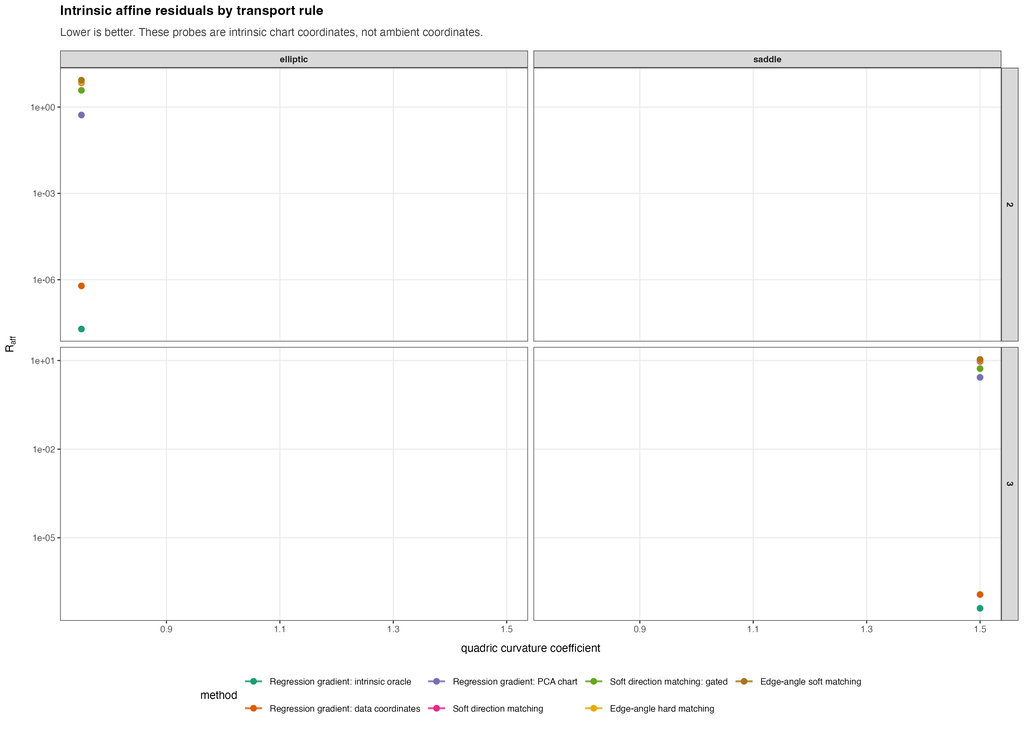

Interpretation: regression-gradient with intrinsic or ambient coordinates is the affine benchmark. Methods that stay close to it are successfully preserving the null space expected of a second-difference-like construction. Methods that sit orders of magnitude higher are not reliable affine annihilators on these data-derived graphs.

# Quadratic And Cubic Probes

The operator should not annihilate all higher-order structure. For quadratic and cubic intrinsic probes we report

$$R_{\mathcal F}
=
\frac{1}{|\mathcal F|}
\sum_{p\in\mathcal F}
\frac{\|A p\|_2}{\|p\|_2},$$

where $\mathcal F$ is either the set of intrinsic monomials $u_i u_j$ or $u_i u_j u_k$. Cubic probes are diagnostics only; this report is still testing order-2 operators.

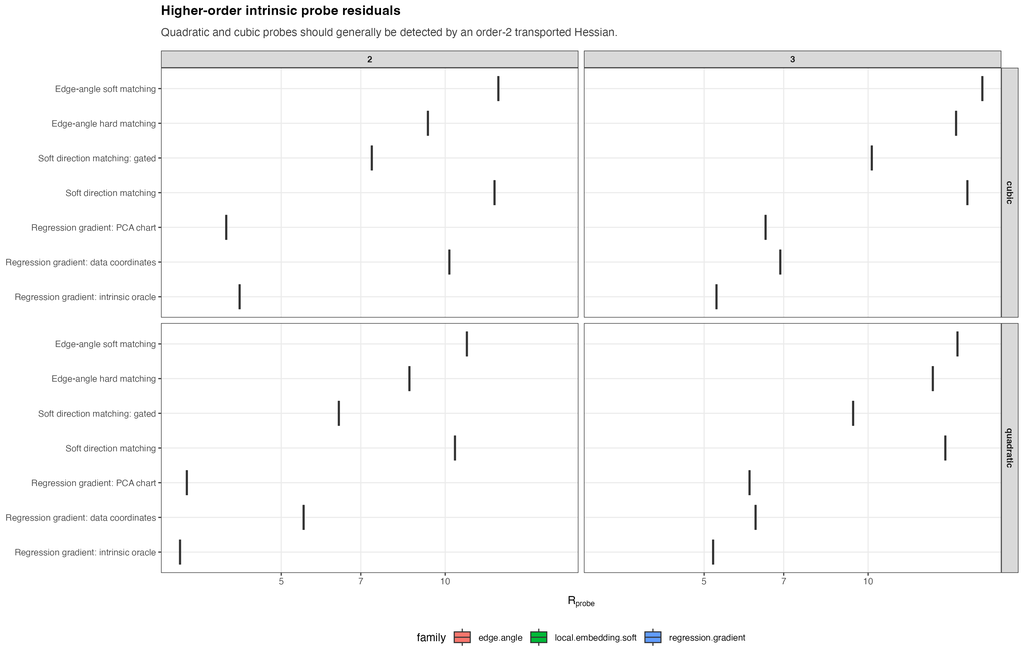

Interpretation: very small affine residual together with nonzero quadratic and cubic residual is the desired qualitative pattern. If a method also drives quadratic residuals to nearly zero, it is too weak for a Hessian-like role.

# Affine Versus Quadratic Separation

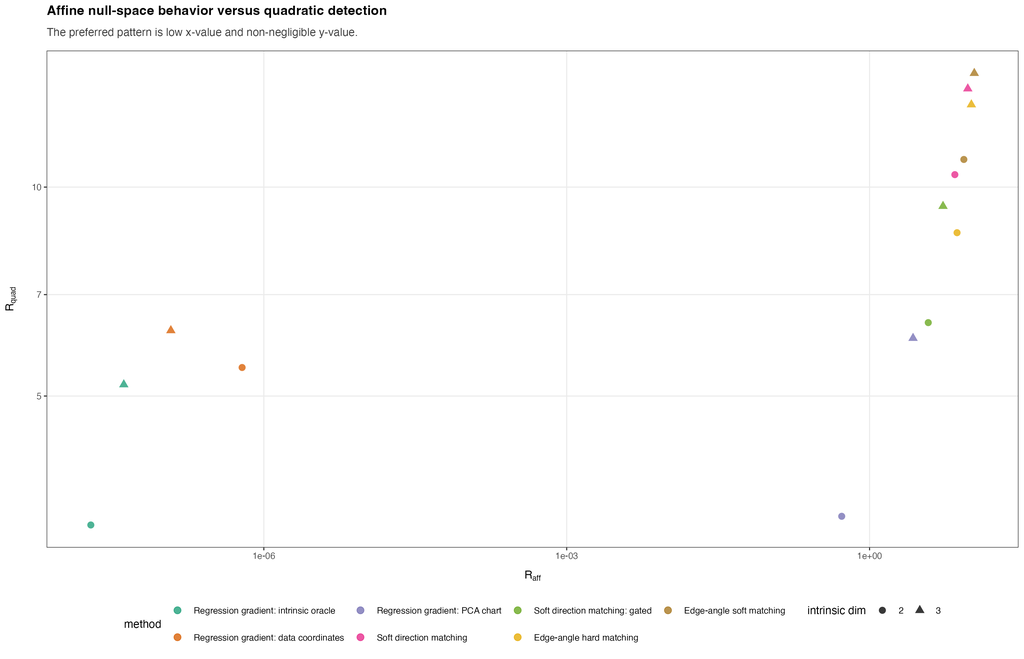

Interpretation: this plot makes clear when a method is failing because it does not annihilate affine functions, versus when it is failing because it has become too weak overall.

# Fractional-Power Probe Panel

Fractional probes use the intrinsic radius

$$\rho(u)=
\frac{\|u-\bar u\|_2}{\max_w\|w-\bar u\|_2}$$

and evaluate $\rho^\alpha$ for non-integer $\alpha$. These are not meant to define a polynomial null space. They are a stress test for whether the operator has a gradual, non-integer response profile rather than an all-or-nothing integer-degree behavior.

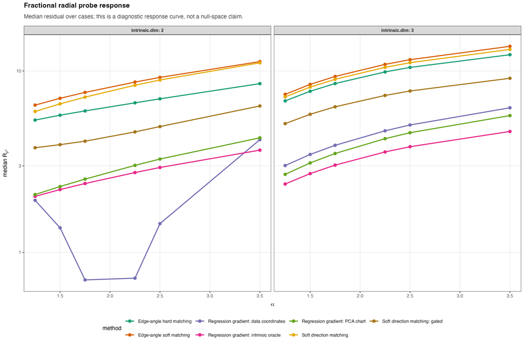

Interpretation: a smooth monotone response is reassuring. A method whose fractional response is erratic is likely being dominated by matching ambiguity or row loss rather than by a clean differential analogy.

# Row Retention And Matching Diagnostics

For match-based methods, low residuals can be misleading if most candidate rows were dropped. We therefore inspect row retention,

$$\mathrm{retention}
=
\frac{\#\{\hbox{accepted rows}\}}
{\#\{\hbox{candidate rows}\}}.$$

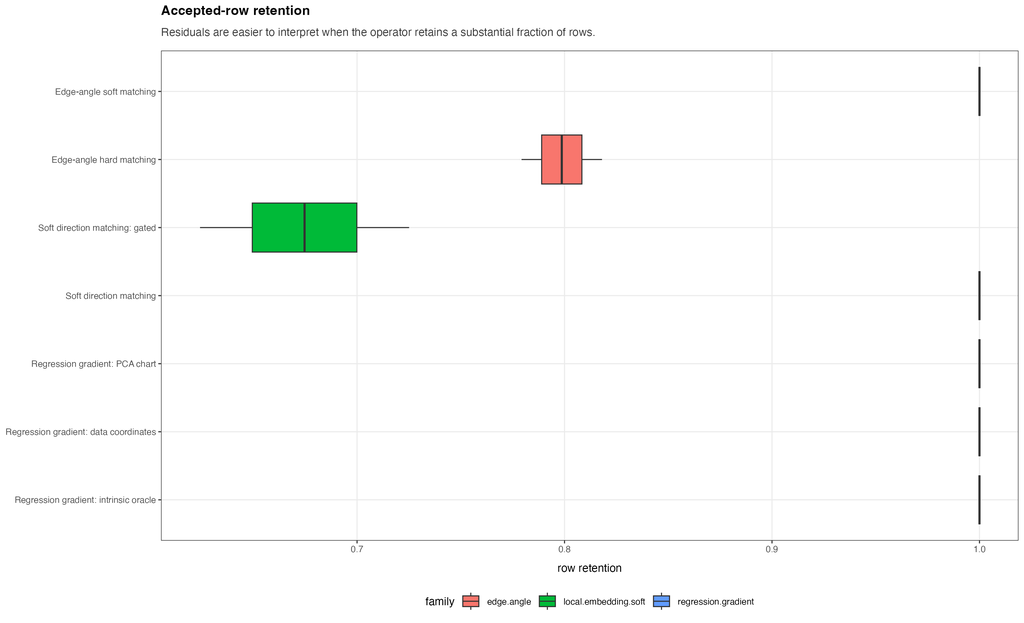

Interpretation: a method that looks good only after aggressive dropping should be treated as a diagnostic filter, not as a stable operator.

# Results Summary

Median diagnostics by method, ranked by affine residual.

|  | method.label | method.family | residual.affine.mean | residual.quadratic.mean | residual.cubic.mean | row.retention |
| --- | --- | --- | --- | --- | --- | --- |
| 5 | Regression gradient: intrinsic oracle | regression.gradient | 0.0000 | 4.2266 | 4.7309 | 1.0000 |
| 6 | Regression gradient: data coordinates | regression.gradient | 0.0000 | 5.8556 | 8.5383 | 1.0000 |
| 7 | Regression gradient: PCA chart | regression.gradient | 1.6128 | 4.7066 | 5.2231 | 1.0000 |
| 4 | Soft direction matching: gated | local.embedding.soft | 4.5771 | 7.8829 | 8.7455 | 0.6747 |
| 3 | Soft direction matching | local.embedding.soft | 8.1953 | 12.1420 | 13.7673 | 1.0000 |
| 1 | Edge-angle hard matching | edge.angle | 8.7748 | 10.8719 | 11.9004 | 0.7987 |
| 2 | Edge-angle soft matching | edge.angle | 9.7418 | 12.7760 | 14.3643 | 1.0000 |

The lowest median affine residual in this run is produced by **Regression gradient: intrinsic oracle**. The preferred transported-Hessian behavior is not only low affine residual, but also nonzero quadratic/cubic residual and healthy row retention. The edge-angle methods are intentionally included here as a new baseline: they test how far one can get from local angle matching alone, before moving to richer direction-transport rules.

# Appendix: Run Status

Run status by method.

|  | method.label | ok |
| --- | --- | --- |
| Edge-angle hard matching | Edge-angle hard matching | 2 |
| Edge-angle soft matching | Edge-angle soft matching | 2 |
| Regression gradient: data coordinates | Regression gradient: data coordinates | 2 |
| Regression gradient: intrinsic oracle | Regression gradient: intrinsic oracle | 2 |
| Regression gradient: PCA chart | Regression gradient: PCA chart | 2 |
| Soft direction matching | Soft direction matching | 2 |
| Soft direction matching: gated | Soft direction matching: gated | 2 |

# Appendix: Reproduction

```r
# Smoke render
Rscript dev/graph-trend-filtering/render_transported_hessian_quadric_multimethod_validation.R

# Full render
GFLOW_QUADRIC_MULTIMETHOD_VALIDATION_MODE=full \
  Rscript dev/graph-trend-filtering/render_transported_hessian_quadric_multimethod_validation.R
```